# Brasileiro_2021_CFA

Eduardo Cecconi

1/4/2022

```r
library(lavaan)
library(tidyverse)
library(readxl)
library(stats)
library(psych)
library(semPlot)
library(stats)
```

# Análise Fatorial Confirmatória

## Dados do Campeonato Brasileiro 2021 extraídos do InStat

Como parte do treinamento em programação e em estatística, submeti dados de scout  
de de 379 dos 380 jogos do Campeonato Brasileiro 2021 (o InStat não disponibilizou  
os dados do jogo Chapecoense 1x1 Athletico, pela 26ª rodada) a diversas técnicas,  
a começar pela Análise Fatorial Confirmatória.

O primeiro passo foi realizar o data wrangling para estruturar o banco de dados  
e proporcionar a elaboração das métricas e dos indicadores que posteriormente  
passarão pelo processo de validação.

Originalmente com 115 variáveis, constatei a ausência de pelo menos 4 informações  
relevantes e fáceis de serem adicionadas ao banco, com o uso da função *case_when()*,  
a partir da criação de uma variável chave para facilitar o código - identificar em  
cada jogo o mandante (H, de Home), e o visitante (A, de Away):

- Pontos (Points)
- Gols Concedidos (Goals_Conceded)
- Chutes Concedidos (Shots_Conceded)
- Finalizações Concedidas em Bolas Paradas (Set_Pieces_Conceded)

```r
Brasileiro_2021 <- read_excel("Brasileiro_Matchs_2021.xlsx")

Brasileiro_2021 <- Brasileiro_2021 %>%
                      mutate(Local = rep(c("H", "A"), times = 379)) %>%
                      select(1:3, Local, everything())

Brasileiro_2021 <- Brasileiro_2021 %>%
                      mutate(Goals_Conceded = case_when(
                              Brasileiro_2021$Local == "H" ~ lead(Brasileiro_2021$Goals),
                              Brasileiro_2021$Local == "A" ~ lag(Brasileiro_2021$Goals)),
                             Set_Pieces_Conceded = case_when(
                              Brasileiro_2021$Local == "H" ~ lead(Brasileiro_2021$`Attacks with shots 0 Set pieces attacks` ),
                              Brasileiro_2021$Local == "A" ~ lag(Brasileiro_2021$`Attacks with shots 0 Set pieces attacks`)),
                             Shots_Conceded = case_when(
                              Brasileiro_2021$Local == "H" ~ lead(Brasileiro_2021$`Shots on target`),
                              Brasileiro_2021$Local == "A" ~ lag(Brasileiro_2021$`Shots on target`))) %>%
                             select(1:5, Goals_Conceded, Shots_Conceded, Set_Pieces_Conceded, everything())

Brasileiro_2021 <- Brasileiro_2021 %>%
                      mutate(Points = case_when(
                            Brasileiro_2021$Goals == Brasileiro_2021$Goals_Conceded ~ 1,
                            Brasileiro_2021$Goals > Brasileiro_2021$Goals_Conceded ~ 3,
                            Brasileiro_2021$Goals < Brasileiro_2021$Goals_Conceded ~ 0)) %>%
                      select(1:3, Points, everything())
```

Das 120 variáveis resultantes, filtrei apenas 39 para construir as métricas,  
em um novo banco de dados, onde foram transformadas em 12 indicadores-chave em um  
arquivo com 24 variáveis no total. Os termos utilizados no código estão em inglês  
(como *CFA*, de *Confirmatory Factor Analysis*), para facilitar a futura tradução  
do artigo.

```r
Metrics_CFA <- Brasileiro_2021 %>% select(Teams, Points, Goals, Goals_Conceded,
                                             `Accurate passes`, Fouls, Passes,
                                             `Key passes accurate`, `Ball recoveries`,
                                             `Ball possession, %`, `Ball possessions, quantity`,
                                             `Ball recoveries in opponent's half`,
                                             `Team pressing successful`, `Opponent's xG`,
                                             `xG (Expected goals)`, `Dribbles successful`,
                                             `Defensive challenges won`,  Building0ups,
                                             `Ball interceptions`, `High pressing successful`,
                                             `Low pressing successful`, `Expected points`,
                                             `Opponent's passes per defensive action`,
                                             `Average duration of ball possession, min`,
                                             `Positional attacks with shots`,
                                             `Counter0attacks with a shot`, `Yellow cards`,
                                             `Red cards`, `Crosses accurate`,
                                             `Attacking challenges won`,
                                             `Air challenges won`, `Tackles successful`,
                                             `Lost balls`, `Lost balls in own half`,
                                             `Entrances on opponent's half`,
                                             `Entrances on final third of opponent's half`,
                                             `Entrances to the opponent's box`,
                                             `Attacks with shots 0 Set pieces attacks`,
                                              Set_Pieces_Conceded, Shots_Conceded) %>%
                                       rename(Expected_Points = `Expected points`,
                                              xG = `xG (Expected goals)`,
                                              Positional_shot = `Positional attacks with shots`,
                                              Counter_shot = `Counter0attacks with a shot`,
                                              Set_Piece_shot = `Attacks with shots 0 Set pieces attacks`,
                                              Key_Passes_acc = `Key passes accurate`,
                                              Crosses_acc = `Crosses accurate`,
                                              Dribbles_acc = `Dribbles successful`,
                                              xG_Conceded = `Opponent's xG`,
                                              Interceptions = `Ball interceptions`,
                                              Team_Pressing = `Team pressing successful`,
                                              High_press_acc = `High pressing successful`,
                                              Low_press_acc = `Low pressing successful`,
                                              Recoveries = `Ball recoveries`,
                                              Recoveries_High = `Ball recoveries in opponent's half`,
                                              PPDA = `Opponent's passes per defensive action`,
                                              Duels_def = `Defensive challenges won`,
                                              Duels_ata = `Attacking challenges won`,
                                              Duels_air = `Air challenges won`,
                                              Tackles_acc = `Tackles successful`,
                                              Yellow_Card = `Yellow cards`,
                                              Red_Card = `Red cards`,
                                              Passes_acc = `Accurate passes`,
                                              Possession_Time = `Ball possession, %`,
                                              Possession_Quant = `Ball possessions, quantity`,
                                              Time_per_possession = `Average duration of ball possession, min`,
                                              Build_Total = Building0ups,
                                              Lost_Balls = `Lost balls`,
                                              Lost_Balls_own = `Lost balls in own half`,
                                              Second_third = `Entrances on opponent's half`,
                                              Final_third = `Entrances on final third of opponent's half`,
                                              Box = `Entrances to the opponent's box`) %>%
                                       mutate(Conversion = Goals / xG,
                                              Conversion_Points = Points / Expected_Points,
                                              Attacks_Shot = Positional_shot +
                                                             Counter_shot + Set_Piece_shot,
                                              Shot_Assist = Key_Passes_acc + Crosses_acc,
                                              Conversion_Conceded = Goals_Conceded /
                                                                    xG_Conceded,
                                              Imposition = (Duels_def + Duels_ata + Duels_air) -
                                                           (Fouls + Red_Card + Yellow_Card),
                                              Contention = log(Tackles_acc + Recoveries +
                                                           Interceptions + Low_press_acc),
                                              Pressing = Recoveries_High + High_press_acc +
                                                         Team_Pressing,
                                              Ball_Care = log((Passes_acc + Dribbles_acc) - Lost_Balls),
                                              Passing_Speed = 10* ((Passes / Possession_Quant) /
                                                              Time_per_possession),
                                              Build_Up = Build_Total - Lost_Balls_own,
                                              Progression = (Second_third - Final_third) +
                                                            (Final_third - Box)) %>%
                                       select(Teams, Points, Expected_Points,
                                              Conversion_Points, Goals, xG, Attacks_Shot,
                                              Conversion, Shot_Assist, Goals_Conceded,
                                              xG_Conceded, Conversion_Conceded, Shots_Conceded,
                                              Contention, Pressing, Imposition, PPDA,
                                              Possession_Time, Passing_Speed, Ball_Care,
                                              Build_Up, Progression, Set_Piece_shot,
                                              Set_Pieces_Conceded)
```

Em resumo, estes são os conceitos utilizados na elaboração das métricas:

- *Conversion:* razão entre os gols marcados e a expectativa de gol (xG), para  
  privilegiar a eficiência;
- *Attacks_Shot:* soma dos chutes realizados em 3 origens distintas de ataques  
  (Posicionais, Transições e Bolas Paradas), o que na execução em si da AFC tem  
  pouca importância, mas pode subsidiar paralelamente gráficos para identificar  
  diferentes estilos de jogo ofensivo;
- *Shot_Assist:* soma dos passes-decisivos e dos cruzamentos que geraram  
  finalização;
- *Conversion_Conceded:* razão entre gols sofridos e expectativa concedida;
- *Imposition:* soma das vitórias pessoais em três tipos de duelos listados  
  (ofensivos, defensivos e aéreos), subtraída a soma de três tipos de infrações  
  (faltas cometidas, cartões amarelos e vermelhos recebidos);
- *Contention:* soma de quatro ações defensivas listadas: tackles (um item de scout  
  comum nas plataformas dominantes mas que, na prática, não existe no Brasil, onde  
  o conceito disseminado é uma espécie de fusão entre tackles e recoveries - a  
  *Roubada*), recuperações, interceptações e pressão baixa eficiente;
- *Pressing:* soma de três ações de pressão listadas: recuperações no campo de  
  ataque, pressão alta eficiente e o que o InStat chama de “team pressing”, e que  
  embora vago quando analisado nos vídeos, é uma espécie de “pressão na bola”;
- *Ball_Care:* relação entre passes certos e dribles certos com as perdas de bola;
- *Passing_Speed:* este indicador é uma adaptação do conceito de VEL (velocidade  
  de circulação da bola); sem a cronologia das ações nos dados extraídos, estimei o  
  tempo individual de retenção da bola por jogada através do cruzamento de três  
  variáveis originais: passes certos, quantidade de posses de bola e tempo médio  
  (em segundos) de cada posse;
- *Build-up:* subtração entre a variável “construção”, disponibilizada nos dados  
  originais, e perdas de bola no próprio campo;
- *Progression:* relação entre as quantidades de ingressos da equipe do campo de  
  defesa para o de ataque, do campo de ataque para o terço final, e do terço final  
  para a área adversária;
- *PPDA:* Passes permitidos por ação defensiva, em inglês, variável que já foi  
  entregue originalmente pelo InStat, sem necessitar de manipulação. Conta a  
  quantidade de passes que o adversário troca na construção até que a equipe realize  
  alguma ação defensiva.

Como as correlações, variâncias e covariâncias são a base deste método, podemos  
explorar as respectivas tabelas, aplicadas ao novo banco de dados:

```r
correlation <- cor(Metrics_CFA[ , 2:24])

covariance <- cov(Metrics_CFA[ , 2:24])

variance <- var(Metrics_CFA[ , 2:24])
```

Além disso, também é importante ajustar as relações de medidas entre métricas que  
resultaram em escalas distintas, o que poderia causar problemas para interpretar  
os resultados, fechando com o arredondamento para duas casas decimais.

```r
Metrics_CFA[, c(7, 13:17, 20:22)] <- apply(Metrics_CFA[, c(7, 13:17, 20:22)],  2, scale)

Metrics_CFA <- Metrics_CFA %>% mutate_if(is.numeric, round, 2)
```

Serão testadas *quatro variáveis latentes* (os indicadores-chave, ou fatores) em  
separado, e depois todas agrupadas em um único modelo: *Ataque, Defesa, Posse e* *Bolas Paradas.* A aritmética é simples, apenas somas, porque carecem de maior  
estudo estatístico para envolverem pesos atribuídos com multiplicações, etc.

## ATAQUE

O modelo de ataque relaciona quatro variáveis: *gols marcados, conversão, chutes*  
*e assistências para finalização*.

Os índices de ajuste foram baixos: CFI = 0.696 (ideal acima de 0.9); TLI = 0.088  
(ideal acima de 0.9); RMSEA = 0.435 (ideal entre 0.05 e 0.08) e SRMR = 0.183 (ideal  
inferior a 0.05).

Não é motivo para desânimo, entretanto. Futebol, sabe-se, é um esporte onde a  
imprevisibilidade interfere mais do que em outros esportes, e muito mais se  
comparado a dados oriundos do mundo empresarial. Muitas vezes a elaboração de  
indicadores no futebol não é relevante para prever resultados, e sim para  
*identificar padrões de comportamento*, para *identificar o estilo* de cada  
equipe, e aí sim agregar informação relevante para a comissão técnica basear  
decisões.

```r
Attack_Model <- ' Attack =~ Goals + Conversion + Attacks_Shot + Shot_Assist '

Fit_Attack_Model <- cfa(Attack_Model, data= Metrics_CFA)

summary(Fit_Attack_Model, fit.measures = TRUE, standardized = TRUE)
```

```
## lavaan 0.6-9 ended normally after 100 iterations
##
##   Estimator                                         ML
##   Optimization method                           NLMINB
##   Number of model parameters                         8
##
##   Number of observations                           758
##
## Model Test User Model:
##
##   Test statistic                               288.719
##   Degrees of freedom                                 2
##   P-value (Chi-square)                           0.000
##
## Model Test Baseline Model:
##
##   Test statistic                               949.481
##   Degrees of freedom                                 6
##   P-value                                        0.000
##
## User Model versus Baseline Model:
##
##   Comparative Fit Index (CFI)                    0.696
##   Tucker-Lewis Index (TLI)                       0.088
##
## Loglikelihood and Information Criteria:
##
##   Loglikelihood user model (H0)              -5029.148
##   Loglikelihood unrestricted model (H1)      -4884.789
##
##   Akaike (AIC)                               10074.297
##   Bayesian (BIC)                             10111.342
##   Sample-size adjusted Bayesian (BIC)        10085.939
##
## Root Mean Square Error of Approximation:
##
##   RMSEA                                          0.435
##   90 Percent confidence interval - lower         0.393
##   90 Percent confidence interval - upper         0.478
##   P-value RMSEA <= 0.05                          0.000
```

[output cut: 11 more lines]

```
## Latent Variables:
##                    Estimate  Std.Err  z-value  P(>|z|)   Std.lv  Std.all
##   Attack =~
##     Goals             1.000                                  NA       NA
##     Conversion       -0.311    0.205   -1.515    0.130       NA       NA
##     Attacks_Shot     -0.086    0.047   -1.842    0.065       NA       NA
##     Shot_Assist      -0.113    0.066   -1.699    0.089       NA       NA
##
## Variances:
##                    Estimate  Std.Err  z-value  P(>|z|)   Std.lv  Std.all
##    .Goals             3.577    1.682    2.127    0.033    3.577    3.255
##    .Conversion        1.302    0.175    7.434    0.000    1.302    1.226
##    .Attacks_Shot      1.017    0.054   18.904    0.000    1.017    1.018
##    .Shot_Assist      13.991    0.721   19.417    0.000   13.991    1.002
##     Attack           -2.478    1.662   -1.491    0.136       NA       NA
```

## DEFESA

```r
Defense_Model <- ' Defense =~ Goals_Conceded + Pressing + Conversion_Conceded + Contention + PPDA + Shots_Conceded '

Fit_Defense_Model <- cfa(Defense_Model, data= Metrics_CFA)

summary(Fit_Defense_Model, fit.measures = TRUE, standardized = TRUE)
```

```
## lavaan 0.6-9 ended normally after 26 iterations
##
##   Estimator                                         ML
##   Optimization method                           NLMINB
##   Number of model parameters                        12
##
##   Number of observations                           758
##
## Model Test User Model:
##
##   Test statistic                               226.962
##   Degrees of freedom                                 9
##   P-value (Chi-square)                           0.000
##
## Model Test Baseline Model:
##
##   Test statistic                              1038.594
##   Degrees of freedom                                15
##   P-value                                        0.000
##
## User Model versus Baseline Model:
##
##   Comparative Fit Index (CFI)                    0.787
##   Tucker-Lewis Index (TLI)                       0.645
##
## Loglikelihood and Information Criteria:
##
##   Loglikelihood user model (H0)              -6104.384
##   Loglikelihood unrestricted model (H1)      -5990.903
##
##   Akaike (AIC)                               12232.768
##   Bayesian (BIC)                             12288.336
##   Sample-size adjusted Bayesian (BIC)        12250.231
##
## Root Mean Square Error of Approximation:
##
##   RMSEA                                          0.179
##   90 Percent confidence interval - lower         0.159
##   90 Percent confidence interval - upper         0.199
##   P-value RMSEA <= 0.05                          0.000
```

[output cut: 15 more lines]

```
##     Pressing         -0.045    0.018   -2.501    0.012   -0.064   -0.064
##     Conversn_Cncdd    0.384    0.051    7.585    0.000    0.538    0.522
##     Contention       -0.082    0.021   -3.910    0.000   -0.114   -0.115
##     PPDA              0.047    0.018    2.590    0.010    0.066    0.066
##     Shots_Conceded    0.268    0.041    6.575    0.000    0.375    0.375
##
## Variances:
##                    Estimate  Std.Err  z-value  P(>|z|)   Std.lv  Std.all
##    .Goals_Conceded   -0.863    0.229   -3.772    0.000   -0.863   -0.785
##    .Pressing          0.995    0.051   19.512    0.000    0.995    0.996
##    .Conversn_Cncdd    0.773    0.051   15.048    0.000    0.773    0.728
##    .Contention        0.985    0.050   19.594    0.000    0.985    0.987
##    .PPDA              0.994    0.051   19.515    0.000    0.994    0.996
##    .Shots_Conceded    0.858    0.047   18.458    0.000    0.858    0.859
##     Defense           1.962    0.227    8.640    0.000    1.000    1.000
```

## POSSE

O modelo de posse relaciona seis variáveis: *tempo de posse, velocidade de circulação,*  
*proteção, construção, progressão e imposição*. Temos uma tendência natural a  
associar o conceito de imposição com a defesa, mas como os dados envolvem todos os  
tipos de ações que o InStat considera “duelos” (muitos dos duelos ofensivos e aéreos  
não têm relação com ações defensivas, portanto), esta métrica serve como referência  
de obtenção de posse.

Embora novamente sem atingir os índices ideais de ajuste, o desempenho no teste  
também melhorou (comparado à defesa, à exceção do RMSEA):  
CFI = 0.833 (ideal acima de 0.9); TLI = 0.721 (ideal acima de 0.9); RMSEA = 0.242  
(ideal entre 0.05 e 0.08) e SRMR = 0.081 (ideal inferior a 0.05).

```r
Possession_Model <- ' Possession =~ Possession_Time + Passing_Speed + Ball_Care + Build_Up + Progression + Imposition '

Fit_Possession_Model <- cfa(Possession_Model, data= Metrics_CFA)

summary(Fit_Possession_Model, fit.measures = TRUE, standardized = TRUE)
```

```
## lavaan 0.6-9 ended normally after 41 iterations
##
##   Estimator                                         ML
##   Optimization method                           NLMINB
##   Number of model parameters                        12
##
##   Number of observations                           758
##
## Model Test User Model:
##
##   Test statistic                               410.171
##   Degrees of freedom                                 9
##   P-value (Chi-square)                           0.000
##
## Model Test Baseline Model:
##
##   Test statistic                              2414.314
##   Degrees of freedom                                15
##   P-value                                        0.000
##
## User Model versus Baseline Model:
##
##   Comparative Fit Index (CFI)                    0.833
##   Tucker-Lewis Index (TLI)                       0.721
##
## Loglikelihood and Information Criteria:
##
##   Loglikelihood user model (H0)              -2417.196
##   Loglikelihood unrestricted model (H1)      -2212.110
##
##   Akaike (AIC)                                4858.391
##   Bayesian (BIC)                              4913.960
##   Sample-size adjusted Bayesian (BIC)         4875.855
##
## Root Mean Square Error of Approximation:
##
##   RMSEA                                          0.242
##   90 Percent confidence interval - lower         0.223
##   90 Percent confidence interval - upper         0.263
##   P-value RMSEA <= 0.05                          0.000
```

[output cut: 15 more lines]

```
##     Passing_Speed     1.258    0.095   13.202    0.000    0.095    0.453
##     Ball_Care        12.861    0.339   37.924    0.000    0.976    0.977
##     Build_Up         10.055    0.379   26.526    0.000    0.763    0.764
##     Progression       6.905    0.440   15.700    0.000    0.524    0.524
##     Imposition        0.756    0.487    1.552    0.121    0.057    0.057
##
## Variances:
##                    Estimate  Std.Err  z-value  P(>|z|)   Std.lv  Std.all
##    .Possession_Tim    0.002    0.000   14.051    0.000    0.002    0.239
##    .Passing_Speed     0.035    0.002   19.250    0.000    0.035    0.794
##    .Ball_Care         0.046    0.015    3.133    0.002    0.046    0.046
##    .Build_Up          0.416    0.023   17.745    0.000    0.416    0.417
##    .Progression       0.724    0.038   19.134    0.000    0.724    0.725
##    .Imposition        0.995    0.051   19.465    0.000    0.995    0.997
##     Possession        0.006    0.000   14.841    0.000    1.000    1.000
```

## BOLAS PARADAS

Este modelo tem a relação entre apenas duas métricas: *finalizações realizadas e* *concedidas em bolas paradas*. Embora seja um item muito relevante sob a ótica  
dos treinadores, sempre atentos a padrões de bolas paradas que possam ser prevenidos  
ou aproveitados nas partidas, estatisticamente o modelo não conseguiu ser identificado.

Para o fator ser testado, foi preciso restringir as cargas com o uso do *a**, um  
conceito com o qual ainda não estou familiarizado, e que retira potencial informativo  
deste indicador. Por enquanto, com os dados disponíveis no banco extraído para  
realizar este teste, das bolas paradas não se consegue obter informação relevante.

```r
Set_Pieces_Model <- ' Set_Pieces =~ a*Set_Piece_shot + a*Set_Pieces_Conceded '

Fit_Set_Pieces_Model <- cfa(Set_Pieces_Model, data= Metrics_CFA)

summary(Fit_Set_Pieces_Model, fit.measures = TRUE, standardized = TRUE)
```

```
## lavaan 0.6-9 ended normally after 13 iterations
##
##   Estimator                                         ML
##   Optimization method                           NLMINB
##   Number of model parameters                         3
##
##   Number of observations                           758
##
## Model Test User Model:
##
##   Test statistic                                 0.000
##   Degrees of freedom                                 0
##
## Model Test Baseline Model:
##
##   Test statistic                                18.626
##   Degrees of freedom                                 1
##   P-value                                        0.000
##
## User Model versus Baseline Model:
##
##   Comparative Fit Index (CFI)                    1.000
##   Tucker-Lewis Index (TLI)                       1.000
##
## Loglikelihood and Information Criteria:
##
##   Loglikelihood user model (H0)              -3032.736
##   Loglikelihood unrestricted model (H1)      -3032.736
##
##   Akaike (AIC)                                6071.472
##   Bayesian (BIC)                              6085.364
##   Sample-size adjusted Bayesian (BIC)         6075.838
##
## Root Mean Square Error of Approximation:
##
##   RMSEA                                          0.000
##   90 Percent confidence interval - lower         0.000
##   90 Percent confidence interval - upper         0.000
##   P-value RMSEA <= 0.05                             NA
##
## Standardized Root Mean Square Residual:
##
##   SRMR                                           0.000
##
## Parameter Estimates:
##
##   Standard errors                             Standard
##   Information                                 Expected
##   Information saturated (h1) model          Structured
##
## Latent Variables:
##                    Estimate  Std.Err  z-value  P(>|z|)   Std.lv  Std.all
##   Set_Pieces =~
##     Set_Pc_sht (a)    1.000                                  NA       NA
##     St_Pcs_Cnc (a)    1.000                                  NA       NA
##
## Variances:
##                    Estimate  Std.Err  z-value  P(>|z|)   Std.lv  Std.all
##    .Set_Piece_shot    3.744    0.225   16.662    0.000    3.744    1.156
##    .Set_Pics_Cncdd    3.744    0.225   16.662    0.000    3.744    1.156
##     Set_Pieces       -0.505    0.119   -4.238    0.000       NA       NA
```

## MODELO FINAL

Com a irrelevância estatística do modelo de bolas paradas, devido à superficialidade  
dos dados disponíveis, este fator foi excluído do modelo final, evitando problemas  
na execução do código.

A ordem das métricas dentro dos indicadores também foi alterada, porque na definição  
dos modelos a primeira variável recebe carga padrão = 1, e se tornou importante que  
os gols feitos e sofridos não passessem por este filtro.

```r
Total_Model <- '
              Attack =~ Conversion + Goals + Attacks_Shot + Shot_Assist
              Defense =~ Conversion_Conceded + Goals_Conceded + Pressing + Contention + PPDA + Shots_Conceded
              Possession =~ Possession_Time + Passing_Speed + Ball_Care + Build_Up + Progression + Imposition
              kpi =~ Possession + Attack + Defense
              '

Fit_Total_Model <- cfa(Total_Model, data= Metrics_CFA, check.gradient = FALSE)

summary(Fit_Total_Model, fit.measures = TRUE, standardized = TRUE)
```

```
## lavaan 0.6-9 ended normally after 204 iterations
##
##   Estimator                                         ML
##   Optimization method                           NLMINB
##   Number of model parameters                        35
##
##   Number of observations                           758
##
## Model Test User Model:
##
##   Test statistic                              2468.783
##   Degrees of freedom                               101
##   P-value (Chi-square)                           0.000
##
## Model Test Baseline Model:
##
##   Test statistic                              5952.620
##   Degrees of freedom                               120
##   P-value                                        0.000
##
## User Model versus Baseline Model:
##
##   Comparative Fit Index (CFI)                    0.594
##   Tucker-Lewis Index (TLI)                       0.518
##
## Loglikelihood and Information Criteria:
##
##   Loglikelihood user model (H0)             -13547.078
##   Loglikelihood unrestricted model (H1)     -12312.687
##
##   Akaike (AIC)                               27164.157
##   Bayesian (BIC)                             27326.231
##   Sample-size adjusted Bayesian (BIC)        27215.091
##
## Root Mean Square Error of Approximation:
##
##   RMSEA                                          0.176
##   90 Percent confidence interval - lower         0.170
##   90 Percent confidence interval - upper         0.182
##   P-value RMSEA <= 0.05                          0.000
```

[output cut: 44 more lines]

```
##    .Goals_Conceded   -0.854    0.225   -3.801    0.000   -0.854   -0.777
##    .Pressing          0.995    0.051   19.518    0.000    0.995    0.995
##    .Contention        0.986    0.050   19.586    0.000    0.986    0.988
##    .PPDA              0.994    0.051   19.519    0.000    0.994    0.995
##    .Shots_Conceded    0.856    0.046   18.448    0.000    0.856    0.857
##    .Possession_Tim    0.002    0.000   13.955    0.000    0.002    0.237
##    .Passing_Speed     0.035    0.002   19.244    0.000    0.035    0.796
##    .Ball_Care         0.049    0.015    3.381    0.001    0.049    0.050
##    .Build_Up          0.415    0.023   17.719    0.000    0.415    0.416
##    .Progression       0.721    0.038   19.114    0.000    0.721    0.722
##    .Imposition        0.995    0.051   19.465    0.000    0.995    0.997
##    .Attack           -0.225    0.137   -1.644    0.100       NA       NA
##    .Defense           0.288    0.049    5.885    0.000    0.996    0.996
##    .Possession        0.005    0.002    2.899    0.004    0.833    0.833
##     kpi               0.001    0.002    0.588    0.557    1.000    1.000
```

Como esperado, os índices de ajuste ficaram baixos, o que não invalida essa metodologia  
de análise de indicadores aplicada ao futebol. É preciso ampliar o estudo sobre  
as possibilidades matemáticas estatisticamente amparadas na formulação das relações  
entre as métricas que compõem os indicadores, atribuindo diferentes pesos; e também  
é importante reiterar a análise como instrumento de identificação de padrões e de  
estilos de jogo, sem deixar de olhar para volumes e eficiências.

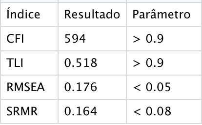

```r
fit_indices <- c("Índice", "Resultado", "Parâmetro", "CFI", 0594, "> 0.9", "TLI", 0.518, "> 0.9",
                 "RMSEA", 0.176, "< 0.05", "SRMR", 0.164, "< 0.08")

fit_indices_tabela <- matrix(fit_indices, nrow = 5, ncol = 3, byrow = TRUE)
```

A visualização do modelo é simples, com os indicadores de primeira ordem ataque,  
posse e defesa relacionados com o KPI (Key Performance Indicator), que soma todos  
os demais:

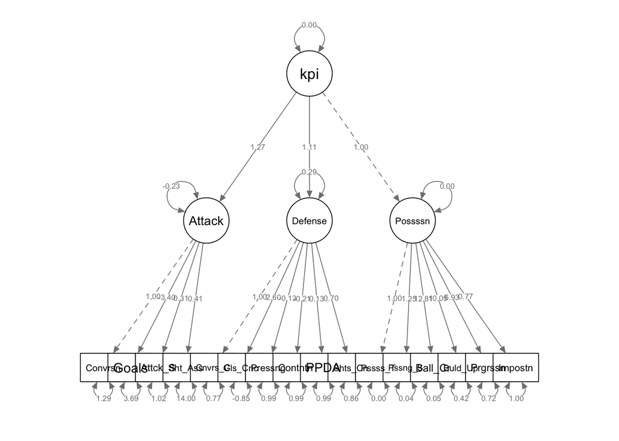

```r
semPaths(Fit_Total_Model, "par", weighted = FALSE, nCharNodes = 7, shapeMan = "rectangle",
         sizeMan = 8, sizeMan2 = 5)
```

## Ranking

Apesar de a AFC não ter encontrado indicadores altos de relevância para o modelo,  
o objetivo da análise fatorial neste caso, desde o início, foi a criação de um  
ranking das equipes do Brasileiro 2021. Para isto, os fatores latentes precisam  
ser construídos não apenas apontando as relações (como ocorreu no modelo), mas  
também seguindo as operações matemáticas - na defesa, por exemplo, os gols sofridos,  
o perigo concedido e os chutes permitidos subtraem o valor total das ações  
defensivas como pressão, contenção e PPDA. E, devido à importância do tema para  
a análise de comportamentos, incluí o indicador de bolas paradas no cálculo,  
contrariando o modelo avaliado e ignorando a superficialidade dos dados.

```r
ranking <- Metrics_CFA %>% mutate(Attack = Conversion + Goals + Attacks_Shot + Shot_Assist,
                                     Defense = (Pressing + Contention + PPDA) -
                                       (Conversion_Conceded + Goals_Conceded + Shots_Conceded),
                                     Possession = Possession_Time + Passing_Speed +
                                       Ball_Care + Build_Up + Progression + Imposition,
                                     Set_Pieces = Set_Piece_shot - Set_Pieces_Conceded,
                                     KPI = Attack + Defense + Possession + Set_Pieces) %>%
                              select(Teams, KPI, Attack, Defense, Possession, Set_Pieces)

ranking[, c(2:6)] <- apply(Metrics_CFA[, c(2:6)],  2, scale)

ranking <- ranking %>% mutate_if(is.numeric, round, 2)

ranking_total <- ranking %>% group_by(Teams) %>%
                             summarise(Attack_Total=sum(Attack),
                                       Defense_Total=sum(Defense),
                                       Possession_Total=sum(Possession),
                                       Set_Pieces=sum(Set_Pieces),
                                       KPI_Total = sum(KPI)) %>%
                             select(Teams, KPI_Total, Attack_Total, Defense_Total, Possession_Total, Set_Pieces) %>%
                             arrange(desc(KPI_Total))
```

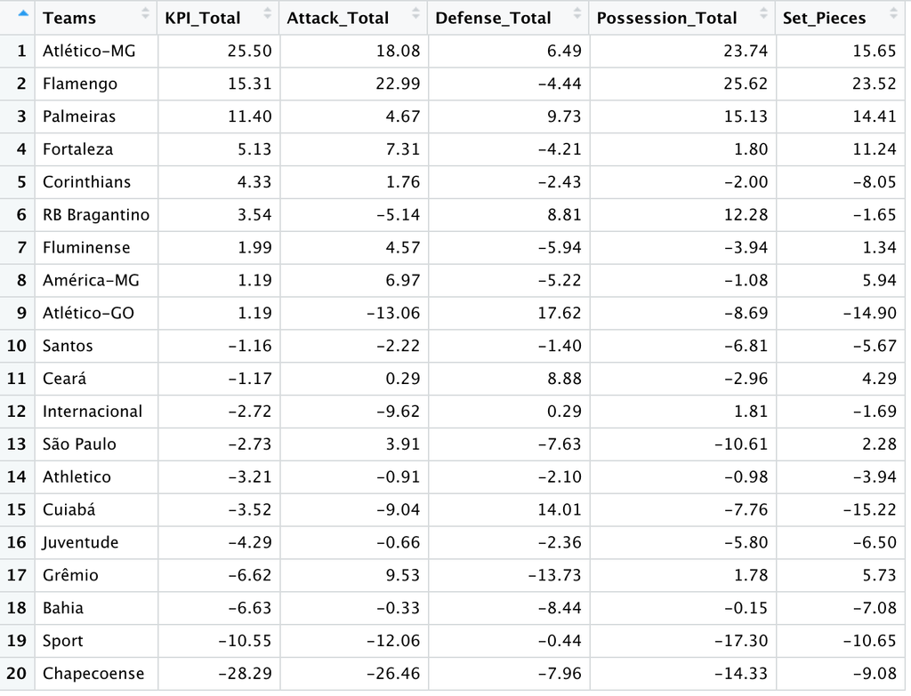

*Gráficos e demais análises das variáveis originais e das métricas*, proporcionando  
mais subsídios para a análise do desempenho das equipes do Brasileiro 2021, serão  
também disponibilizados em *artigos onde testarei não apenas a regressão múltipla,* *mas também a análise fatorial exploratória*.